# GLOE-Seq analysis CTCF binding sites and DHS

```r
library(wigglescout)
library(ggplot2)
library(reshape2)
library(dplyr)
library(ggpubr)
library(GenomicRanges)


source('../lib/lib_embed_data.v1.0.R')

data_path <- '/Volumes/DATA/DATA/GLOE/GLOE/replicates/'

replicates <- c("WT-UT-1-1","WT-UT-1-2","WT-UT-1-3","WT-20-2-1","WT-20-2-2","WT-20-2-3","WT-24hr-3-1","WT-24hr-3-2","WT-24hr-3-3","KO-UT-4-1","KO-UT-4-2","KO-UT-4-3","KO-20-5-1","KO-20-5-2","KO-20-5-3","KO-24hr-6-1","KO-24hr-6-2","KO-24hr-6-3")
samples <- c("WT-UT-1","WT-20-2","WT-24hr-3","KO-UT-4","KO-20-5","KO-24hr-6")

build_filenames <- function(path, cond) {
  files <- paste0(path,"/GL-",cond,".hg19.bs50.bw")
  labels <- paste0("GLOE ", cond)
  return(data.frame(files=files,labels=labels))
}

build_filenames_plus <- function(path, cond) {
  files <- paste0(path,"/GL-",cond,".hg19.R1plus.bw")
  labels <- paste0("GLOE (+) ", cond)
  return(data.frame(files=files,labels=labels))
}

build_filenames_minus <- function(path, cond) {
  files <- paste0(path,"//GL-",cond,".hg19.R1minus.bw")
  labels <- paste0("GLOE (-) ", cond)
  return(data.frame(files=files,labels=labels))
}
```

## Published peaksets (Cistrome)

Here, we are comparing profiles accross known accessible, DNAase hypersensitive regions, and CTCF peaks *Note: unlike in previous plots, we clearly see now a correlation of CAD activity and accessible chromatin. Plotting average profiles on scarce read data can be thrown of by artifact regions. These artifacts are avoided here by 1) using a blacklist to remove known repetitive/artifact-prone regions and 2) removing outliers (top 0.1%) of the signal before averaging.*

```r
fn <- build_filenames(data_path,samples)

p1 <- plot_bw_profile(bwfiles = fn$files,labels = fn$labels,mode = "center",upstream = 1000, downstream = 1000, loci = "../genome/HCT116_ATACseq.hg19.bed", bin_size = 10 ,remove_top = 0.001, verbose=F)
```

```r
p2 <- plot_bw_profile(bwfiles = fn$files,labels = fn$labels,mode = "center",upstream = 1000, downstream = 1000, loci = "../genome/HCT116_CTCF.hg19.bed", bin_size = 10 ,remove_top = 0.001, verbose=F)
```

```r
p3 <- plot_bw_profile(bwfiles = fn$files,labels = fn$labels,mode = "center",upstream = 1000, downstream = 1000, loci = "../genome/HCT116_DHS.hg19.bed", bin_size = 10 ,remove_top = 0.001, verbose=F)
```

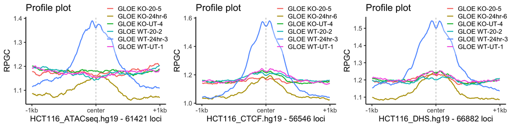

```r
ggarrange(p1, p2, p3, ncol = 3, nrow = 1)
```

```r
embed_last_plot("profile-ctcf-atac-dhs")
```

Download profile-ctcf-atac-dhs.pdf

## CTCF sites - spacing relative to nucleosomes and linker histone

around CTCF sites, the GLOE-seq signal looked very periodic, which suggested that there could be a relationship to nucleosome occupancy. Indeed, the pattern is consistent with CAD cutting left and right of linker histone / in-between linker histone and nucleosome. Note that the same periodicity is also seen in untreated and CAD KO conditions, albeit much less pronounced, suggesting that CAD-independent SSBs are also occuring more often in-between nucleosomes.

```r
plus <- build_filenames_plus(data_path,samples)
minus <- build_filenames_minus(data_path,samples)

histones <- c('/Volumes/DATA/DATA/GLOE/GLOE/GEO/Torres2016_H10_1.hg19.bw','/Volumes/DATA/DATA/GLOE/GLOE/GEO/Torres2016_H14_2.hg19.bw','/Volumes/DATA/DATA/GLOE/GLOE/GEO/U2OS_AcH3_ChIPseq.hg19.bw')

p1<- plot_bw_profile(bwfiles = histones[1],labels = c("H1.0"),mode = "center",upstream = 1000, downstream = 1000, loci = "../genome/HCT116_CTCF.hg19.bed", bin_size = 10, verbose = F, remove_top = 0.0001)
```

```r
p2<- plot_bw_profile(bwfiles = histones[2],labels = c("H1.4"),mode = "center",upstream = 1000, downstream = 1000, loci = "../genome/HCT116_CTCF.hg19.bed", bin_size = 10, verbose = F, remove_top = 0.0001)
```

```r
p3<- plot_bw_profile(bwfiles = histones[3],labels = c("H3ac"),mode = "center",upstream = 1000, downstream = 1000, loci = "../genome/HCT116_CTCF.hg19.bed", bin_size = 10, verbose = F, remove_top = 0.0001)
```

```r
p4<- plot_bw_profile(bwfiles = c(plus$files[3],minus$files[3]),labels = c("WT 24h +","WT 24h -"),mode = "center",upstream = 1000, downstream = 1000, loci = "../genome/HCT116_CTCF.hg19.bed", bin_size = 10, verbose = F, remove_top = 0.0001)
```

```r
p5 <- plot_bw_profile(bwfiles = plus$files[c(1,3,6)],labels = plus$labels[c(1,3,6)],mode = "center",upstream = 1000, downstream = 1000, loci = "../genome/HCT116_CTCF.hg19.bed", bin_size = 10, verbose = F, remove_top = 0.0001)
```

```r
p6 <- plot_bw_profile(bwfiles = minus$files[c(1,3,6)],labels = minus$labels[c(1,3,6)],mode = "center",upstream = 1000, downstream = 1000, loci = "../genome/HCT116_CTCF.hg19.bed", bin_size = 10, verbose = F, remove_top = 0.0001)
```

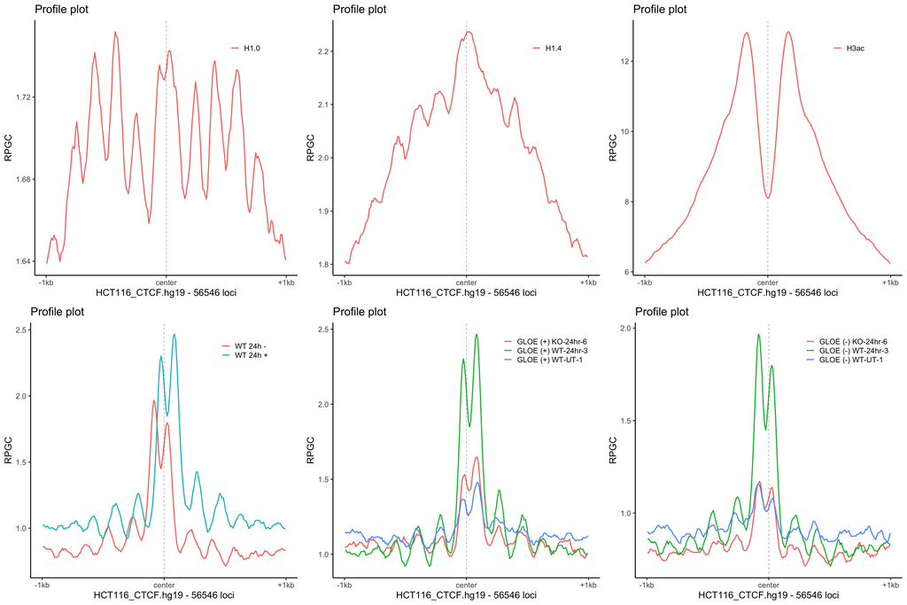

```r
ggarrange(p1, p2, p3, p4, p5, p6, ncol = 3, nrow = 2)
```

```r
embed_last_plot("profile-ctcf-pos")
```

Download profile-ctcf-pos.pdf

## DNase hypersensitive sites - spacing relative to nucleosomes and linker histone

With the removal of artifactual regions, we now also can see a neatly spaced pattern at DNAse hypersensitive sites.

```r
plus <- build_filenames_plus(data_path,samples)
minus <- build_filenames_minus(data_path,samples)

histones <- c('/Volumes/DATA/DATA/GLOE/GLOE/GEO/Torres2016_H10_1.hg19.bw','/Volumes/DATA/DATA/GLOE/GLOE/GEO/Torres2016_H14_2.hg19.bw','/Volumes/DATA/DATA/GLOE/GLOE/GEO/U2OS_AcH3_ChIPseq.hg19.bw')

p1<- plot_bw_profile(bwfiles = histones[1],labels = c("H1.0"),mode = "center",upstream = 1000, downstream = 1000, loci = "../genome/HCT116_DHS.hg19.bed", bin_size = 10, verbose = F, remove_top = 0.0001)
```

```r
p2<- plot_bw_profile(bwfiles = histones[2],labels = c("H1.4"),mode = "center",upstream = 1000, downstream = 1000, loci = "../genome/HCT116_DHS.hg19.bed", bin_size = 10, verbose = F, remove_top = 0.0001)
```

```r
p3<- plot_bw_profile(bwfiles = histones[3],labels = c("H3ac"),mode = "center",upstream = 1000, downstream = 1000, loci = "../genome/HCT116_DHS.hg19.bed", bin_size = 10, verbose = F, remove_top = 0.0001)
```

```r
p4<- plot_bw_profile(bwfiles = c(plus$files[3],minus$files[3]),labels = c("WT 24h +","WT 24h -"),mode = "center",upstream = 1000, downstream = 1000, loci = "../genome/HCT116_DHS.hg19.bed", bin_size = 10, verbose = F, remove_top = 0.0001)
```

```r
p5 <- plot_bw_profile(bwfiles = plus$files[c(1,3,6)],labels = plus$labels[c(1,3,6)],mode = "center",upstream = 1000, downstream = 1000, loci = "../genome/HCT116_DHS.hg19.bed", bin_size = 10, verbose = F, remove_top = 0.0001)
```

```r
p6 <- plot_bw_profile(bwfiles = minus$files[c(1,3,6)],labels = minus$labels[c(1,3,6)],mode = "center",upstream = 1000, downstream = 1000, loci = "../genome/HCT116_DHS.hg19.bed", bin_size = 10, verbose = F, remove_top = 0.0001)
```

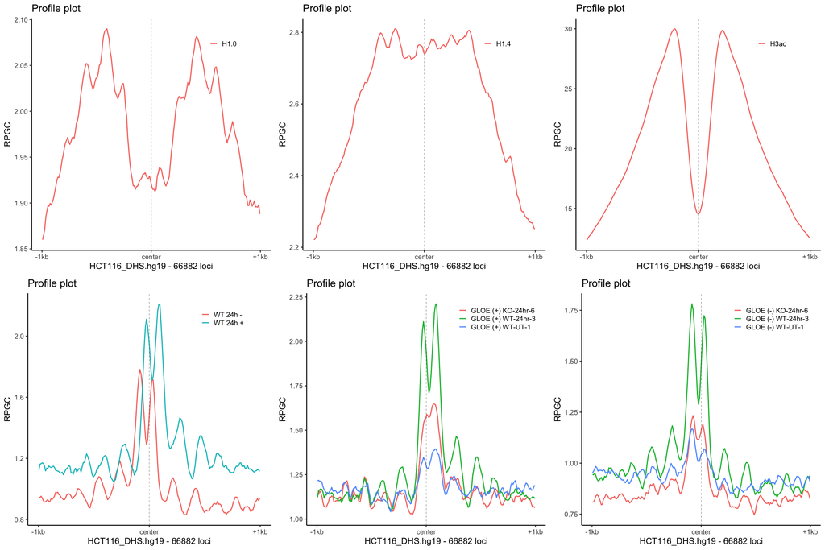

```r
ggarrange(p1, p2, p3, p4, p5, p6, ncol = 3, nrow = 2)
```

```r
embed_last_plot("profile-dhs-pos")
```

Download profile-dhs-pos.pdf